# Final Project Report

Jo Dang

## < Investigating the Data Set >

```r
glimpse(stress)
```

```
## Rows: 630
## Columns: 9
## $ sr...1 <dbl> 93.800, 91.640, 60.000, 85.760, 48.120, 56.880, 47.000, 50.000,…
## $ rr     <dbl> 25.680, 25.104, 20.000, 23.536, 17.248, 19.376, 16.800, 18.000,…
## $ t      <dbl> 91.840, 91.552, 96.000, 90.768, 97.872, 95.376, 97.200, 99.000,…
## $ lm     <dbl> 16.600, 15.880, 10.000, 13.920, 6.496, 9.376, 5.600, 8.000, 4.2…
## $ bo     <dbl> 89.840, 89.552, 95.000, 88.768, 96.248, 94.064, 95.800, 97.000,…
## $ rem    <dbl> 99.60, 98.88, 85.00, 96.92, 72.48, 83.44, 68.00, 80.00, 61.12, …
## $ sr...7 <dbl> 1.840, 1.552, 7.000, 0.768, 8.248, 6.376, 7.800, 9.000, 7.112, …
## $ hr     <dbl> 74.20, 72.76, 60.00, 68.84, 53.12, 58.44, 52.00, 55.00, 50.28, …
## $ sl     <dbl> 3, 3, 1, 3, 0, 1, 0, 0, 0, 1, 2, 1, 0, 4, 3, 1, 1, 3, 3, 2, 2, …
```

There are 9 variables, all of which are numerical. Diving into each specific variable:

sr…1 - snoring rate: ranges 45 - 100

rr - respiration rate: ranges 16 - 30

t - body temperature: ranges 85 - 99

lm - limb movement: ranges 4 - 19

rem - eye movement: ranges 60 - 105

sr…7 - sleeping hours: ranges 0 - 9

hr - heart rate: ranges 50 - 85

sl - stress level: ranges 0 - 4

I picked the database because of the straight forward use implied by its name: “Human Stress Detection in and through Sleep”. So, my intention since the very beginning was to use stress level, or ‘sl’ as the response variable and everything else as explanatory variables.

Number of NA’s:

```r
sum(is.na(stress))
```

```
## [1] 0
```

There are no missing entries.

A quick look at all the variables:

```r
summary(stress)
```

```
##      sr...1             rr             t              lm              bo
##  Min.   : 45.00   Min.   :16.0   Min.   :85.0   Min.   : 4.00   Min.   :82.00
##  1st Qu.: 52.50   1st Qu.:18.5   1st Qu.:90.5   1st Qu.: 8.50   1st Qu.:88.50
##  Median : 70.00   Median :21.0   Median :93.0   Median :11.00   Median :91.00
##  Mean   : 71.60   Mean   :21.8   Mean   :92.8   Mean   :11.70   Mean   :90.90
##  3rd Qu.: 91.25   3rd Qu.:25.0   3rd Qu.:95.5   3rd Qu.:15.75   3rd Qu.:94.25
##  Max.   :100.00   Max.   :30.0   Max.   :99.0   Max.   :19.00   Max.   :97.00
##       rem             sr...7          hr              sl
##  Min.   : 60.00   Min.   :0.0   Min.   :50.00   Min.   :0
##  1st Qu.: 81.25   1st Qu.:0.5   1st Qu.:56.25   1st Qu.:1
##  Median : 90.00   Median :3.5   Median :62.50   Median :2
##  Mean   : 88.50   Mean   :3.7   Mean   :64.50   Mean   :2
##  3rd Qu.: 98.75   3rd Qu.:6.5   3rd Qu.:72.50   3rd Qu.:3
##  Max.   :105.00   Max.   :9.0   Max.   :85.00   Max.   :4
```

Zv/nzv features

```r
nearZeroVar(stress, saveMetrics = TRUE)
```

```
##        freqRatio percentUnique zeroVar   nzv
## sr...1       1.0    99.5238095   FALSE FALSE
## rr           1.0    99.3650794   FALSE FALSE
## t            1.0    99.3650794   FALSE FALSE
## lm           1.0    99.3650794   FALSE FALSE
## bo           1.0    99.3650794   FALSE FALSE
## rem          1.0    99.3650794   FALSE FALSE
## sr...7      63.5    79.5238095   FALSE FALSE
## hr           1.0    99.3650794   FALSE FALSE
## sl           1.0     0.7936508   FALSE FALSE
```

There are no zv/nzv features in the original data

Since the column names are abbreviations and are a bit confusing, I decided to rename them so that we have an easier time looking at reports later on.

```r
stress <- stress %>% rename(snoringRate = sr...1) %>%
rename(respirationRate = rr) %>%
rename(bodyTemp = t) %>%
rename(limbMovement = lm) %>%
rename(bloodOxygen = bo) %>%
rename(eyeMovement = rem) %>%
rename(sleepingHours = sr...7) %>%
rename(heartRate = hr) %>%
rename(stressLevel = sl)

summary(stress)
```

```
##   snoringRate     respirationRate    bodyTemp     limbMovement
##  Min.   : 45.00   Min.   :16.0    Min.   :85.0   Min.   : 4.00
##  1st Qu.: 52.50   1st Qu.:18.5    1st Qu.:90.5   1st Qu.: 8.50
##  Median : 70.00   Median :21.0    Median :93.0   Median :11.00
##  Mean   : 71.60   Mean   :21.8    Mean   :92.8   Mean   :11.70
##  3rd Qu.: 91.25   3rd Qu.:25.0    3rd Qu.:95.5   3rd Qu.:15.75
##  Max.   :100.00   Max.   :30.0    Max.   :99.0   Max.   :19.00
##   bloodOxygen     eyeMovement     sleepingHours   heartRate      stressLevel
##  Min.   :82.00   Min.   : 60.00   Min.   :0.0   Min.   :50.00   Min.   :0
##  1st Qu.:88.50   1st Qu.: 81.25   1st Qu.:0.5   1st Qu.:56.25   1st Qu.:1
##  Median :91.00   Median : 90.00   Median :3.5   Median :62.50   Median :2
##  Mean   :90.90   Mean   : 88.50   Mean   :3.7   Mean   :64.50   Mean   :2
##  3rd Qu.:94.25   3rd Qu.: 98.75   3rd Qu.:6.5   3rd Qu.:72.50   3rd Qu.:3
##  Max.   :97.00   Max.   :105.00   Max.   :9.0   Max.   :85.00   Max.   :4
```

Let’s see if each stress level has an equal number of observations:

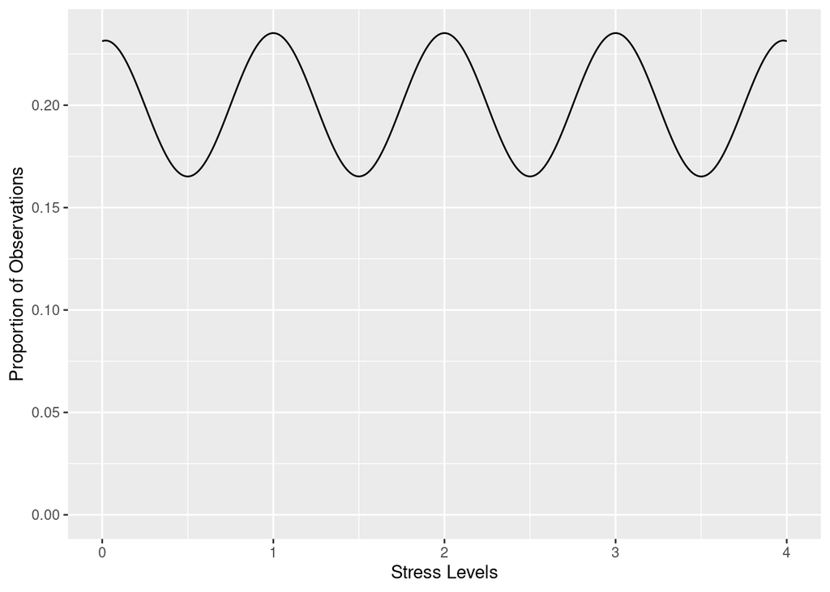

Numbers of Records of All Stress Levels

```r
ggplot(data=stress, aes(x=stressLevel, fill=stressLevel, color=stressLevel)) +
  geom_density(alpha=0.5) + xlab("Stress Levels") + ylab("Proportion of Observations")
```

It seems that we have equal numbers of rows for each level of stress. This leads me to think that we have a data set that is evenly distributed, fair, and able to make equally accurate predictions.

Let’s investigate the relationship between 2 randomly chosen variables and their relationships to stress levels:

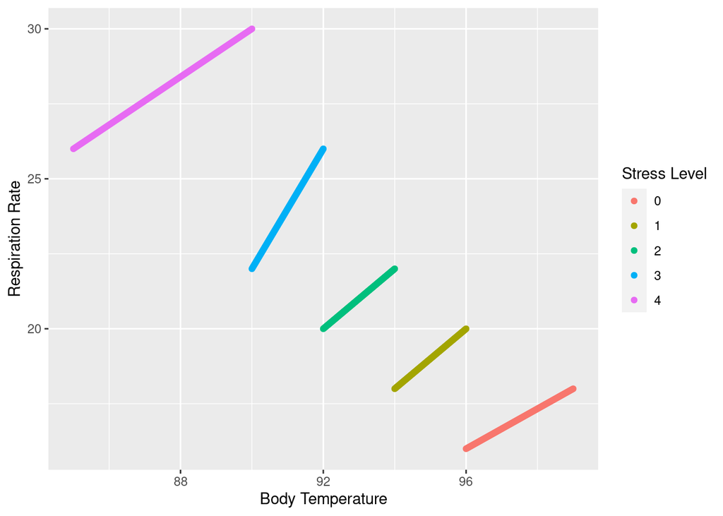

Respiration Rate, Body Temperature, and Stress Levels

```r
ggplot(data=stress, aes(x=bodyTemp, y=respirationRate, color = as.factor(stressLevel))) + geom_point() + xlab("Body Temperature") + ylab("Respiration Rate") + labs(color='Stress Level')
```

It seems that bodyTemp and respirationRate have an inverse correlation. respirationRate and stressLevel has a positive correlation.

Let’s pick another 2 random variables:

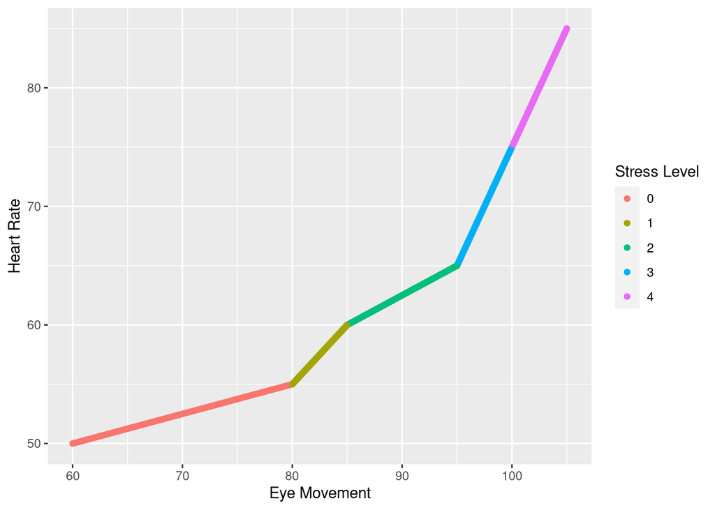

Heart Rate, Eye Movement, and Stress Levels

```r
ggplot(data=stress, aes(x=eyeMovement, y=heartRate, color = as.factor(stressLevel))) + geom_point() + xlab("Eye Movement") + ylab("Heart Rate") + labs(color='Stress Level')
```

All of the variables involved have a positive correlation.

These investigations and graphs are only to provide a bit insight into the possible relationships among the variables in the data set.

## < Working with the Data Set >

# Splitting the data into training and test sets (80-20)

```r
set.seed(888)

index <- createDataPartition(stress$stressLevel, p = 0.8, list = FALSE)
stress_train <- stress[index,]    # training set
stress_test <- stress[-index,]   # test set
```

# Preparing the Blueprint

Fortunately, we don’t need any imputing step because we don’t have any NA values in the data set. Similarly, we also don’t have categorical variables so we don’t need to use step_integer, step_other, and step_dummy. This means that we only need to do scaling on numerical variables. While doing this, we need to use -all_outcomes() because the response variable is also numerical, or we can use all_numeric_predictors() instead of all_numeric().

```r
set.seed(888)

stress_recipe <- recipe(stressLevel ~. , data = stress_train)

blueprint <- stress_recipe %>%
  step_center(all_numeric(), -all_outcomes()) %>%      # center numerical features
  step_scale(all_numeric(), -all_outcomes())       # scale numerical features

prepare <- prep(blueprint, data = stress_train)

baked_train <- bake(prepare, new_data = stress_train)

baked_test <- bake(prepare, new_data = stress_test)
```

# Implementing CV with some ML techniques

```r
set.seed(888)

#Implement 5-fold CV repeated 5 times for each of the models.
cv_specs <- trainControl(method = "repeatedcv", number = 5, repeats = 5)

#Linear Regression
lm_cv <- train(blueprint,
                data = stress_train,
                method = "lm",
                trControl = cv_specs,
                metric = "RMSE")

#KNN
k_grid <- expand.grid(k = seq(1, 101, by = 5))    # for KNN

knn_cv <- train(blueprint,
                data = stress_train,
                method = "knn",
                trControl = cv_specs,
                tuneGrid = k_grid,
                metric = "RMSE")

#LASSO
lambda_grid <- 10^seq(-3, 3, length = 100)    # for LASSO

lasso_cv <- train(blueprint,
                   data = stress_train,
                   method = "glmnet",   # for lasso
                   trControl = cv_specs,
                   tuneGrid = expand.grid(alpha = 1, lambda = lambda_grid),  # alpha = 1 implements lasso
                   metric = "RMSE")

#MARS
param_grid <- expand.grid(degree = 1:3, nprune = seq(1, 100, length.out = 10))   # for MARS

mars_cv <- train(blueprint,
                   data = stress_train,
                   method = "earth",   # for MARS
                   trControl = cv_specs,
                   tuneGrid = param_grid,
                   metric = "RMSE")

# use tuneLength = 20 for the single regression tree

#A single regression tree
tree_cv <- train(blueprint,
                   data = stress_train,
                   method = "rpart",
                   trControl = cv_specs,
                   tuneLength = 20,
                   metric = "RMSE")

#Bagged trees
bag_fit <- bagging(formula = stressLevel~.,
                   data = baked_train,
                   nbagg = 500,
                   coob = TRUE,
                   control = rpart.control(minsplit = 2,
                                           cp = 0,
                                           xval = 0))

#Random forest
param_grid_rf <- expand.grid(mtry = seq(1, 8, 1),    # for random forests
                             splitrule = "variance",
                             min.node.size = 2)

rf_cv <- train(blueprint,
               data = stress_train,
               method = "ranger",
               trControl = cv_specs,
               tuneGrid = param_grid_rf,
               metric = "RMSE")

pcr_cv <- train(blueprint,
                 data = stress_train,
                 method = "pcr",
                 trControl = cv_specs,
                 tuneLength = 20,
                 metric = "RMSE")
```

We know that trees require minimal feature engineering (only require missing entry imputation). So, we are creating a new blueprint with the minimal feature engineering steps, preparing this blueprint on the training data, and doing everything else similarly to what we did above.

```r
set.seed(888)

blueprint_new <- stress_recipe

prepare_new <- prep(blueprint_new, data = stress_train)

baked_train_new <- bake(prepare_new, new_data = stress_train)

baked_test_new <- bake(prepare_new, new_data = stress_test)

#A single regression tree but with minimal feature engineering
tree_cv_min_fe <- train(blueprint_new,
                   data = stress_train,
                   method = "rpart",
                   trControl = cv_specs,
                   tuneLength = 20,                   # considers a grid of 20 possible tuning parameter values
                   metric = "RMSE")

#Bagged trees but with minimal feature engineering
bag_fit_min_fe <- bagging(formula = stressLevel~.,
                   data = baked_train_new,
                   nbagg = 500,
                   coob = TRUE,
                   control = rpart.control(minsplit = 2,
                                           cp = 0,
                                           xval = 0))
#Random forest but with minimal feature engineering
rf_cv_min_fe <- train(blueprint_new,
               data = stress_train,
               method = "ranger",
               trControl = cv_specs,
               tuneGrid = param_grid_rf,
               metric = "RMSE")
```

- Reporting the optimal CV (or, OOB) RMSE of each model and the optimal hyperparameters for each model.

[output not shown]

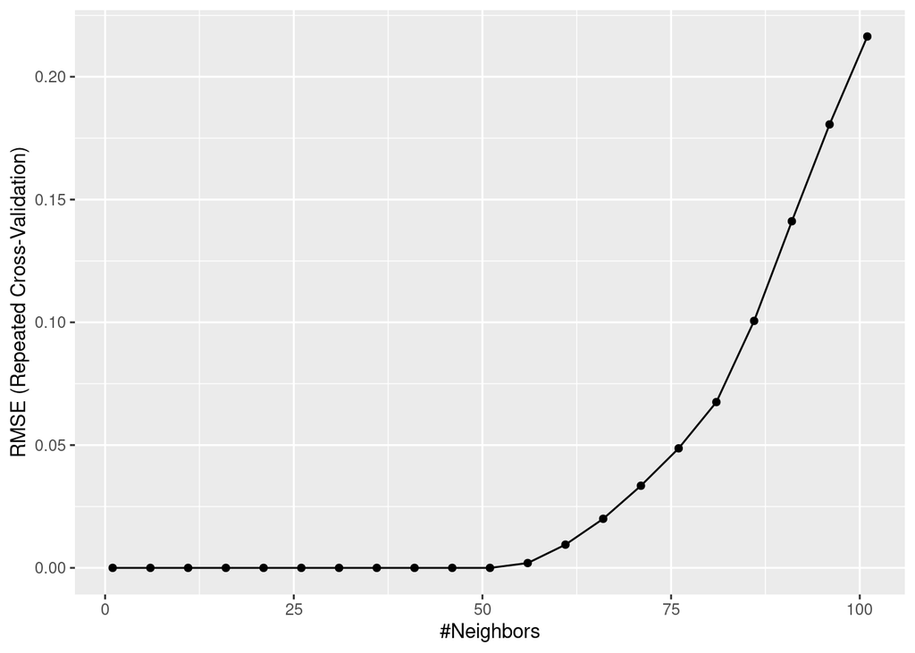

The Corresponding RMSE Values of All k Values

```r
ggplot(knn_cv)   # plot the model training results for different 'k's
```

This graph is unsettling to me, so let’s look at a better graph.

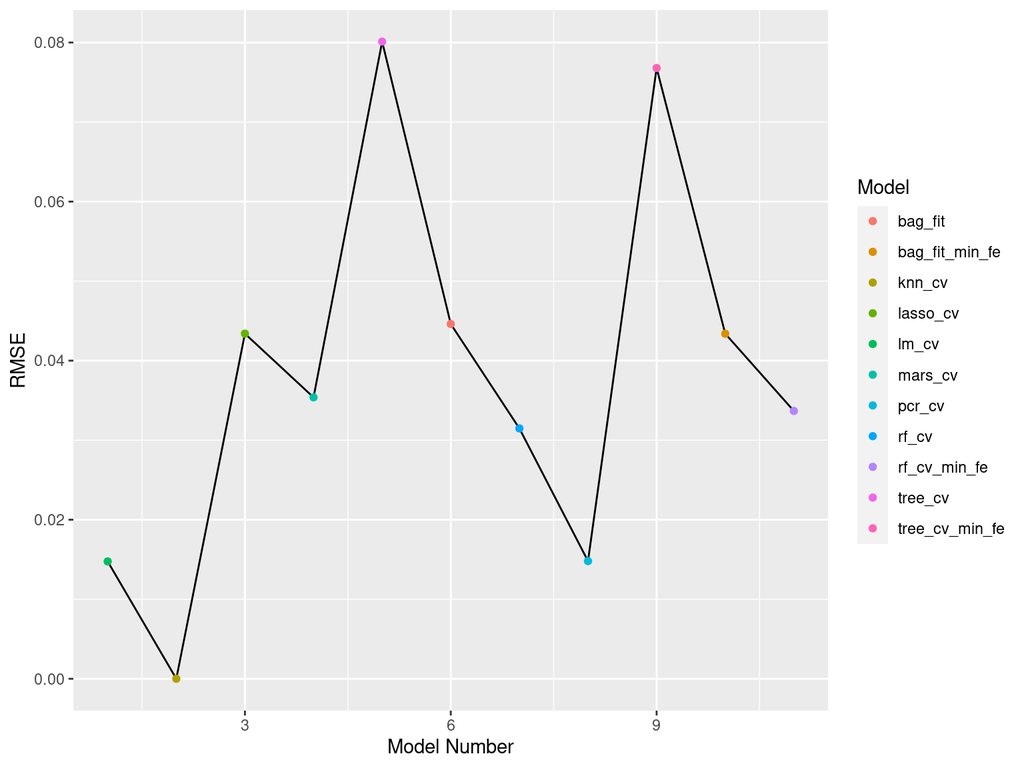

The Lowest RMSE Values of the Models

```r
# compare $k$-fold CV results for different models

# create data frame to plot results
df <- data.frame(model_number = 1:11,
                RMSE = c(min(lm_cv$results$RMSE),
                         min(knn_cv$results$RMSE),
                         min(lasso_cv$results$RMSE),
                         min(mars_cv$results$RMSE),
                         min(tree_cv$results$RMSE),
                         bag_fit$err,
                         min(rf_cv$results$RMSE),
                         min(pcr_cv$results$RMSE),
                         min(tree_cv_min_fe$results$RMSE),
                         bag_fit_min_fe$err,
                         min(rf_cv_min_fe$results$RMSE)),
                model =  c('lm_cv','knn_cv','lasso_cv','mars_cv','tree_cv','bag_fit','rf_cv','pcr_cv','tree_cv_min_fe','bag_fit_min_fe','rf_cv_min_fe'))

# plot results from LOOCV
ggplot(data = df, aes(x = model_number, y =  RMSE)) + geom_line() +
  geom_point(aes(color = model)) + xlab("Model Number") + labs(color='Model')
```

Just to make sure that what we seeing are right, we will look at the RMSE values again in a table, arranged by the RMSE values from lowest to highest.

```r
df %>%
  arrange(RMSE) %>%
  kbl() %>%
  kable_material(c("striped", "hover"))
```

| model_number | RMSE | model |
| --- | --- | --- |
| 2 | 0.0000000 | knn_cv |
| 1 | 0.0147528 | lm_cv |
| 8 | 0.0147959 | pcr_cv |
| 7 | 0.0314781 | rf_cv |
| 11 | 0.0336747 | rf_cv_min_fe |
| 4 | 0.0353834 | mars_cv |
| 10 | 0.0433871 | bag_fit_min_fe |
| 3 | 0.0433941 | lasso_cv |
| 6 | 0.0446074 | bag_fit |
| 9 | 0.0767995 | tree_cv_min_fe |
| 5 | 0.0801181 | tree_cv |

```r
# build final model with optimal 'k' chosen from 'knn_fit' results
knn_cv$finalModel
```

```
## 51-nearest neighbor regression model
```

```r
final_model <- knnreg(stressLevel ~ ., data = baked_train, k = knn_cv$bestTune$k)

# obtain predictions on test data
final_model_preds <- predict(object = final_model, newdata = baked_test)

# estimate prediction error using RMSE
sqrt(mean((baked_test$stressLevel - final_model_preds)^2))    # RMSE
```

```
## [1] 0
```

The test RMSE for the K-NN Model is also 0.

```r
# obtain estimate of prediction error from test data
lm_cv$finalModel
```

```
##
## Call:
## lm(formula = .outcome ~ ., data = dat)
##
## Coefficients:
##     (Intercept)      snoringRate  respirationRate         bodyTemp
##          2.0000           0.1894           0.5039          -0.5714
##    limbMovement      bloodOxygen      eyeMovement    sleepingHours
##         -0.3388           0.1782           0.3837          -0.3392
##       heartRate
##              NA
```

```r
final_model <- lm(stressLevel ~ ., data = baked_train)    # build final model

final_model_preds <- predict(object = final_model, newdata = baked_test)   # obtain predictions on test data

sqrt(mean((baked_test$stressLevel - final_model_preds)^2))
```

```
## [1] 0.01524526
```

The test RMSE for the Linear Regression Model is 0.0152.

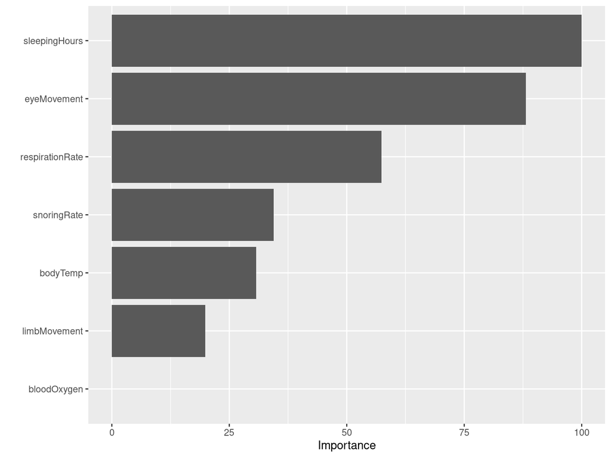

Variable Importance

```r
# variable importance

vip(object = lm_cv,         # CV object
    method = "model")            # model-specific VI scores
```